# Map your dataset!

Athina Hadjixenofontos, Ph.D and Guanhua Chen

6/1/2017

How to use: Please open this R Markdown document in RStudio, so you can add your code into it to make your own maps. See http://rmarkdown.rstudio.com if you are curious about R Markdown.

### Welcome to your first geospatial project

We created this document as a template, so you can focus on learning some of the basics without having to worry about building your project from scratch.

Fortunately, this document is also not something that we made from scratch! We are relying on lots of code written by others, who we call **developers**. These are ordinary people like you and me, who figured out how to e.g. plot the outline of the United States and packaged it up in a **library** so that we can use their code simply by calling the `library()` function.

It really is a community effort.

The gray block below contains R code. You’ll be running the code, seeing what it does, changing it, testing that your changes are doing what you expected they would do, all in these gray boxes. One thing you **won’t** need to change are the first and last lines that contain the backticks `.

```r
library(ggplot2)
library(ggmap)
library(mapdata)
```

### First things first: where is the data?

### About the demonstration data

We will use the libraries dataset throughout this analysis template. The libraries dataset contains data on the location of public libraries in Miami-Dade County, Florida. This wonderful resource is available through the Miami-Dade County GIS Open Data Site at http://gis-mdc.opendata.arcgis.com/. They have digitized and made openly available datasets on lots of categories, like parks, transportation, the environment, and lots more!

#### Demonstration

```r
libraries <- read.csv("../datasets/libraries.csv", header = TRUE)
```

#### Your turn

Now do the same for the dataset you have chosen for your project. In the code block below, type the name you want to use for your dataset, then type in the <- (it’s called the “assignment operator”), and finally use read.csv() in a very similar way as what we did above to read in your own dataset.

Run the command that you wrote, and notice the new dataset appearing in your Environment window on the right! Amazing. You have just loaded your data into the computer’s memory. You can now play with it.

### Okay, so now that the data is in the house, what do I do?

#### Your turn

Let’s do the same for your dataset. In the code block below, type the str() command that will give you information about your dataset.

How many observations do you have in your dataset?

## The geospatial information

#### Demonstration

You will notice that you have one variable called `latitude` and one variable called `longitude` in your dataset. These variables contain values that will help us pin the location of the libraries (or sharks, or contaminated sites, or daycares etc in your dataset), on a map.

##### Note on the interpretation of the standard deviation

NOTE: You can use the interactive console in RStudio as a calculator! Type -80.27599 - 10.23443 in the console window below to calculate the lower bound of the answer.

#### Your turn

In the code block below, type the commands that will return the means and standard deviations of longitudes and latitudes for your dataset.

## Practice example: Mapping a map of the world

So let’s put the Miami-Dade libraries on a map!

In order to do that, let’s start with writing the code to draw a map of the world, as an illustrative example.

#### First, we need the geographic coordinates for the coast of all the continents

Fortunately, others have put together datasets that contain the coordinates for the coastlines of the entire world. Let’s use their dataset. We can find it in a library of code and data called `ggplot2`, which provides access to that data through the function called `map_data()`.

```r
world <- map_data("world")
head(world)
```

|  | long | lat | group | order | region | subregion |
| --- | --- | --- | --- | --- | --- | --- |
| 1 | -69.89912 | 12.45200 | 1 | 1 | Aruba | NA |
| 2 | -69.89571 | 12.42300 | 1 | 2 | Aruba | NA |
| 3 | -69.94219 | 12.43853 | 1 | 3 | Aruba | NA |
| 4 | -70.00415 | 12.50049 | 1 | 4 | Aruba | NA |
| 5 | -70.06612 | 12.54697 | 1 | 5 | Aruba | NA |
| 6 | -70.05088 | 12.59707 | 1 | 6 | Aruba | NA |

The function `head()` shows the first 6 rows of the dataset. As you see, we have variables for latitude and longitude (abbreviated as lat and long), a character variable that indicates the region (e.g. “Aruba”).

#### Second, we need to plot those coordinates

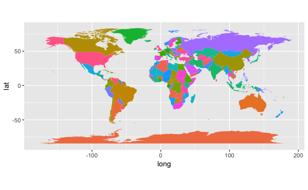

```r
ggplot(data = world) + # make a plot using the world data
  geom_polygon(aes(x = long, # longitude goes on the x-axis
                   y = lat, # latitude goes on the y-axis
                   fill = region, # color by country
                   group = group)) +
  coord_quickmap() + # make sure the map isn't too stretched
  guides(fill = FALSE) # remove the legend
```

Woohoo! You just had the computer draw a map by connecting the dots of all the coastlines! Good job.

#### Demonstration: Let’s zoom-in on Florida, so we can see Miami-Dade county.

**IMPORTANT:** I’ll be using Miami-Dade as my zooming-in area because that’s what’s in the demonstration data. The dataset you chose may not map to Miami-Dade. Instead, your data may map to the coast of west Africa and western Europe, or to the west coast of the United States. Therefore, you should zoom-in to the areas that are in YOUR chosen dataset.

First, we need to only take the coordinates data for countries or states in our dataset, instead of for the entire world.

```r
miamidade <- counties[counties$subregion == "miami-dade"]
```

[output not shown]

NOTE: We will build this map slowly, until we have a map of the counties that we are happy with. Each of the following code blocks will add something to the plot, so you’ll see a lot of the code being repeated. In real life you would only need the finalized version of the code that produces the plot you want. However, seeing how the plot is build layer by layer is useful for training purposes!

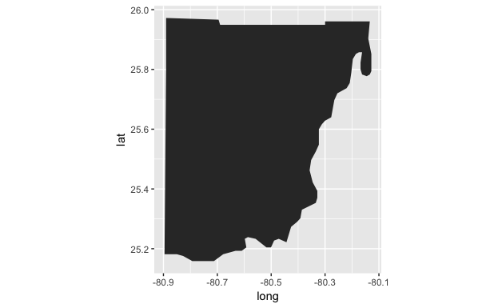

```r
ggplot() +
  geom_polygon(data = miamidade, # geom_polygon to connect the dots, using the florida data
               aes(x = long, # use the variable long on the x axis
                   y = lat, # use the variable lat on the y axis
                   group = group)) +
  coord_quickmap() # make sure the map isn't stretched
```

To make it easier to see other colors that we will map on top, let’s change the fill color from the dark gray to a lighter gray.

Now that we’ve figured out the code for plotting Miami-Dade county, we can save the plot in a variable, so we can access it later.

**Notice:** what are the differences in the code between the block that follows this sentence and the code block above? What do they do?

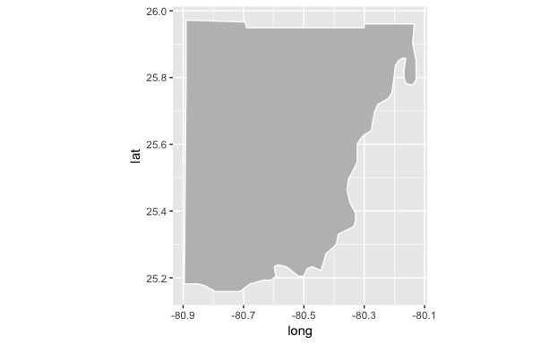

```r
miamidade_map <- ggplot() + # save the plot in a variable named "florida_map"
  geom_polygon(data = miamidade,   # from the Miami-Dade county coordinates dataset
               aes(x = long,       # mark the longitudes
                   y = lat,        # mark the latitudes
                   group = group), # connect the dots in the order specified by the group variable
               fill = "gray",           # fill the polygons with lighter gray
               color = "white") +       # add a white border
  coord_quickmap()
miamidade_map # call the plot named "miamidade_map" to appear on the screen
```

#### Your turn

In the following code block, type the code that will subset the map_data() into the coordinates that are relevant for your mapping project.

Use the code examples from above, and substitute “florida” for the region of interest for your dataset, e.g. “new york”

Awesome! Now, follow the plotting examples above to produce a map of the state or county represented in your dataset.

## We’re so close! Let’s map the libraries on top of Miami-Dade County

First, let’s remind ourselves what we have in our libraries dataset by taking another look.

```r
head(libraries)
```

|  | index | longitude | latitude | branch | address | city | zipcode | phone.number | workdays | hours.open |
| --- | --- | --- | --- | --- | --- | --- | --- | --- | --- | --- |
| 1 | 1 | -80.12074 | 25.86089 | North Shore | 7501 COLLINS AVE | Miami Beach | 33141 | 305 864-5392 | Mon, Tues, Fri, Sat. | 10:00am - 6:00pm |
| 2 | 2 | -80.13771 | 25.77026 | South Shore | 131 ALTON RD | Miami Beach | 33139 | 305 535-4223 | Mon, Tues, Thurs, Sat. | 10:00am - 6:00pm |
| 3 | 3 | -80.28769 | 25.82151 | Miami Springs | 401 WESTWARD DR | Miami Springs | 33166 | 305-805-3811 | Mon, Wed, Thurs, Sat. | 10:00am - 6:00pm |
| 4 | 4 | -80.25145 | 25.90196 | Opa-Locka | 780 FISHERMAN ST | Opa-Locka | 33054 | 305-688-1134 | Mon - Fri | 10:00am - 6:00pm |
| 5 | 5 | -80.22856 | 25.75482 | Shenandoah | 2111 SW 19TH ST | Miami | 33145 | 305-250-4688 | Mon, Wed, Sat. | 10:00am - 6:00pm |
| 6 | 6 | -80.43074 | 25.50632 | Naranja | 14850 SW 280TH ST | Miami | 33032 | 305-242-2290 | Mon, Wed, Fri, Sat. | 10:00am - 6:00pm |

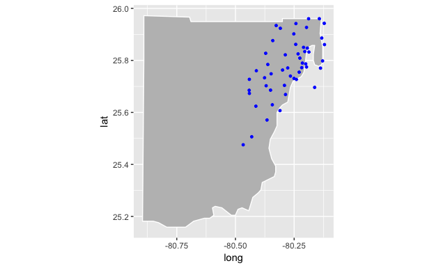

```r
libraries_map <- ggplot() +        # I chose the map name to be "libraries_map"
  geom_polygon(data = miamidade,     # draw the Miami-Dade county perimeter
               aes(x = long,
                   y = lat,
                   group = group),
               fill = "gray",
               color = "white") +
  geom_point(data = libraries,            # draw the positions of the libraries
             aes(x = longitude,
                 y = latitude),
             color = "blue",
             size = 1) +
  coord_quickmap()
libraries_map             # call the saved map to appear on the screen
```

Here you have it! You just drew a map of Miami-Dade county, and annotated it with the locations of the public libraries!

What do you notice about this map? Anything you didn’t expect? What are some of the libraries doing in what seems like the ocean?

## Woohoo! You should feel very proud of yourself. Time to celebrate!